# E. coli lineages under antibiotic exposure

An explained barbac reconstruction of the Jasinska et al. time series

## What this analysis establishes

We reconstructed **six bacterial populations**: three grown with a constant low chloramphenicol concentration and three grown without antibiotic. The selected time series contain **350,934,958 reads across 75 samples**; barbac extraction retained **87.00%**. The three shared initial samples add **13,332,953 reads**. They are processed once and reused as the baseline for all six populations.

All 75 input-read totals match the corresponding published sample totals exactly. For the **20 published dominant barcodes in each population**, the median population-level Spearman rank correlation of final frequencies is **0.9985**. A value near 1 means the two analyses rank these barcodes in a similar order. The mean absolute difference across the 120 entries is **0.548 percentage points** when dividing by all input reads, and **0.066 percentage points** when dividing by extracted barcode reads. Both calculations include absent calls. This is agreement with published measurements, not an accuracy percentage.

**The publication’s final-frequency denominator is unresolved.** One population’s published top-20 frequencies exceed its reported fraction of reads with barcodes. The report therefore shows both explicit normalizations and the source discrepancy.

The publication provides per-sample summary statistics and average/final frequencies for its dominant barcodes. Those tables support the numerical checks shown here. They do not supply the complete author count matrix needed to verify every reconstructed trajectory or every diversity value.

## The experiment, starting from the beginning

The study asks how bacterial lineages compete during prolonged growth under different antibiotic regimens. A **lineage** is a family of cells descended from a labelled ancestor. The researchers inserted a DNA identification tag into the chromosome, mixed many tagged lineages, and followed their relative abundance by sequencing the tags at successive passages. The tag identifies a lineage; its sequence is not itself a measurement of antibiotic resistance. [Jasinska et al., Nature Ecology & Evolution (2020)](https://doi.org/10.1038/s41559-020-1103-z)

Our selected experiment uses **one barcode per lineage, nominally 15 bases long**. The original mixture contains many more lineages than could be studied one by one. We selected two conditions from the constant-concentration experiment: **chloramphenicol at 1 µg/mL** and **no antibiotic**, both in the same supplemented M9 medium. A passage is a transfer into fresh growth medium; the authors use approximately six generations per passage.

Selected populations

All deposited timepoints and sequencing subsamples for these populations

| Condition | Biological replicate | Samples | First passage | Last passage | Sequenced reads |
| --- | --- | --- | --- | --- | --- |
| Chloramphenicol | Low CMP r1 | 12 | 2 | 30 | 51,445,100 |
| Chloramphenicol | Low CMP r2 | 12 | 2 | 30 | 58,044,002 |
| Chloramphenicol | Low CMP r3 | 12 | 2 | 30 | 58,385,766 |
| No antibiotic | No drug r1 | 13 | 1 | 30 | 54,567,025 |
| No antibiotic | No drug r2 | 13 | 1 | 30 | 64,517,158 |
| No antibiotic | No drug r3 | 13 | 1 | 30 | 63,975,907 |

There are three biological repeats per condition. Each sample was deposited in four sequencing subsamples; these four files are pooled into one observation. They do not increase the number of biological replicates. The three initial population samples are pooled into a shared passage-zero reference.

[interactive chart not shown]

Each dot is a sampled timepoint. Connecting segments show the sampling schedule, not observations between samples. The longest gap is between passages 22 and 30. The no-antibiotic populations also have a passage-one sample.

## How DNA reads become lineage counts

The workflow is **FASTQ quality checks → minimum base-quality filtering → mapping to the barcode cassette → barbac extraction → barbac LV clustering → counts over time**. These are single-end reads; there is no paired-read merging or UMI deduplication. Every count in this report is a sequencing-read count, not a direct cell count.

The reference contains 15 placeholder bases at the barcode position. Actual barcodes are extracted from the observed read sequence, preserving variable lengths. Because these reads begin near the barcode, mapping identifies the downstream constant sequence and extraction captures the barcode immediately before it. Our explicitly documented flank rule differs from the authors’ custom alignment rule; the extraction comparison measures that difference.

Read accounting

Each percentage uses all input reads in the same condition

| Condition | Samples | Input reads | Quality passed | Mapped reads | Extracted barcode reads | Retained |
| --- | --- | --- | --- | --- | --- | --- |
| Chloramphenicol | 36 | 167,874,868 | 167,827,016 | 150,814,667 | 148,095,645 | 88.22% |
| No antibiotic | 39 | 183,060,090 | 183,008,998 | 160,650,526 | 157,231,352 | 85.89% |

Reads must have Phred quality at least 10 at every sequenced base. Only primary alignments enter the mapping count, so supplementary alignments cannot count a read twice. “Retained” describes extraction yield and does not measure correct clustering.

[interactive chart not shown]

These bars use barbac’s own mapping plot. They partition quality-passed reads into mapped and unmapped observations. Reads rejected by the quality filter are already excluded here; the table above retains the original-input denominator.

Extraction yield compared with the publication

Weighted by input reads within each population

| Population | Barbac retained | Published retained | Difference (pp) |
| --- | --- | --- | --- |
| Low CMP r1 | 84.77% | 85.89% | −1.12 |
| Low CMP r2 | 90.84% | 92.03% | −1.19 |
| Low CMP r3 | 88.64% | 89.80% | −1.16 |
| No drug r1 | 89.79% | 91.18% | −1.39 |
| No drug r2 | 83.46% | 84.65% | −1.19 |
| No drug r3 | 85.02% | 86.22% | −1.20 |

The publication reports rounded extraction fractions. A higher yield is not evidence of higher accuracy; the extraction rules differ.

## Extraction diagnostics explained: A, B, C and D

These panels use the existing **`barbac_xtr.stats()`** calculations. They describe distinct extracted sequences **before clustering**, when several sequences may still be errors derived from the same lineage. Each sequence contributes once to each histogram, regardless of its read count.

- **A — Length:** the horizontal axis is barcode length in bases; the vertical axis counts distinct sequences. The design length is 15. Dashed lines at 14 and 16 delimit the near-nominal group used in panel D; they are not extraction filters. Extraction accepts 10–20 bases, and the published dominant-barcode table itself contains some shorter-than-15 sequences.
- **B — Abundance:** how many sequences have each read count. On the log₁₀ axis, 0 means one read, 1 means ten reads, and 2 means one hundred reads.
- **C — Base-composition entropy:** how evenly A, C, G and T occur within an individual sequence. `AAAA` has 0 bits; `ACGT` has 2 bits. This measure ignores base order: a repetitive `ACGTACGT` also has 2 bits. It is not a direct score of sequence randomness, sequencing accuracy, or population diversity.
- **D — Length summary:** a native `gt` table. “Sequences” counts distinct DNA strings; “Reads” sums their observations. The two percentage columns therefore have different denominators, explicitly named in the footnote.

Expand a population/timepoint below. Early and final samples are shown for all six populations. The complete sample statistics are available in the accompanying extraction summary CSV.

**Low CMP r1 · passage 2**

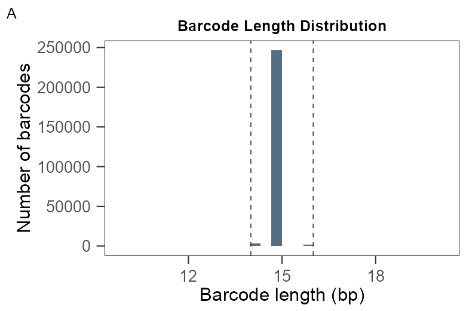

Panel A: barcode length, A3_p02

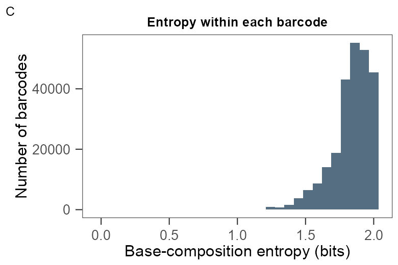

Panel C: base-composition entropy, A3_p02

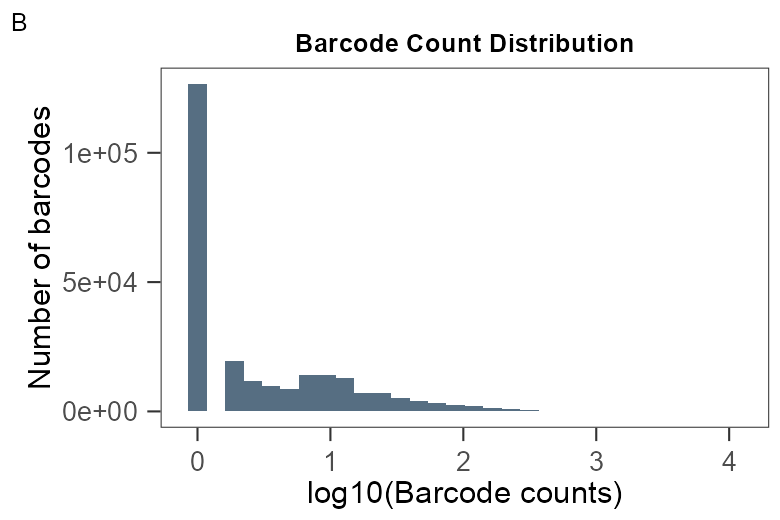

Panel B: barcode abundance, A3_p02

D · Length summary

| Length group | Sequences | Reads | Of sequences | Of reads |
| --- | --- | --- | --- | --- |
| 14 - 16 bp | 251,273 | 3,156,341 | 99.7% | 99.7% |
| < 14 bp | 757 | 7,885 | 0.3% | 0.2% |
| > 16 bp | 54 | 200 | 0.0% | 0.0% |

Sequence share = group sequences / all extracted sequences. Read share = group reads / all extracted reads. Rounded shares may not sum to exactly 100%.

**Low CMP r1 · passage 30**

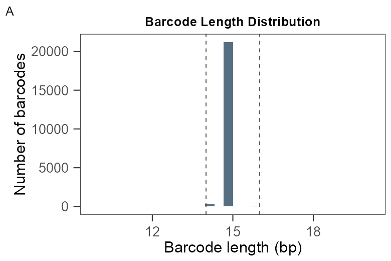

Panel A: barcode length, A3_p30

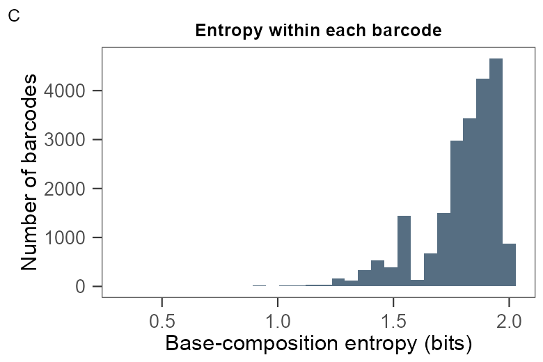

Panel C: base-composition entropy, A3_p30

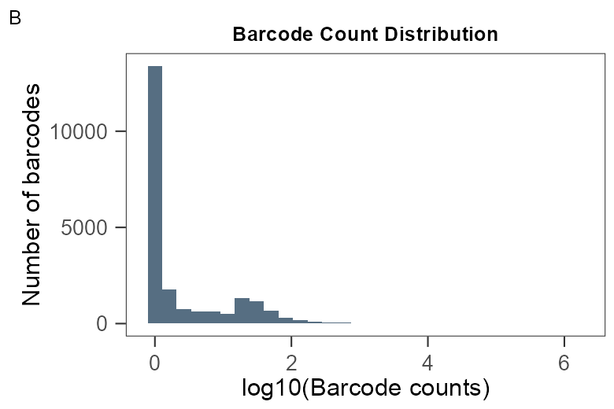

Panel B: barcode abundance, A3_p30

D · Length summary

| Length group | Sequences | Reads | Of sequences | Of reads |
| --- | --- | --- | --- | --- |
| 14 - 16 bp | 21,544 | 3,254,866 | 99.6% | 100.0% |
| < 14 bp | 71 | 413 | 0.3% | 0.0% |
| > 16 bp | 12 | 16 | 0.1% | 0.0% |

Sequence share = group sequences / all extracted sequences. Read share = group reads / all extracted reads. Rounded shares may not sum to exactly 100%.

**Low CMP r2 · passage 2**

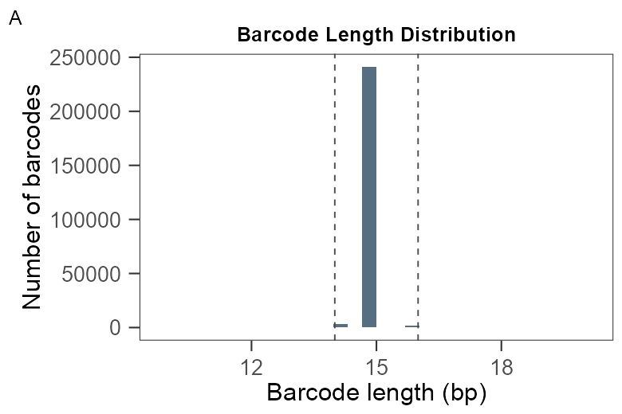

Panel A: barcode length, B3_p02

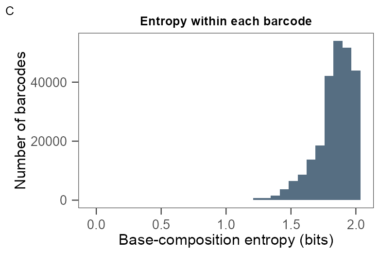

Panel C: base-composition entropy, B3_p02

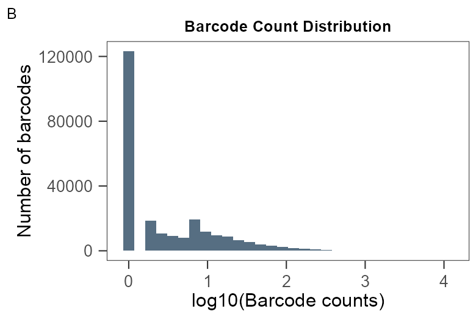

Panel B: barcode abundance, B3_p02

D · Length summary

| Length group | Sequences | Reads | Of sequences | Of reads |
| --- | --- | --- | --- | --- |
| 14 - 16 bp | 245,770 | 3,213,979 | 99.7% | 99.8% |
| < 14 bp | 643 | 7,253 | 0.3% | 0.2% |
| > 16 bp | 39 | 219 | 0.0% | 0.0% |

Sequence share = group sequences / all extracted sequences. Read share = group reads / all extracted reads. Rounded shares may not sum to exactly 100%.

**Low CMP r2 · passage 30**

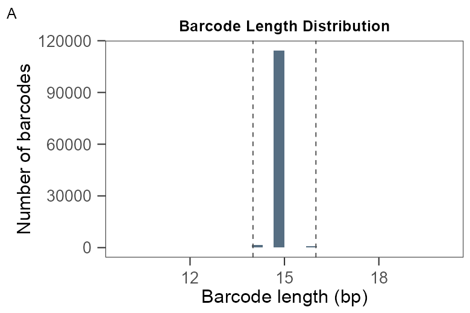

Panel A: barcode length, B3_p30

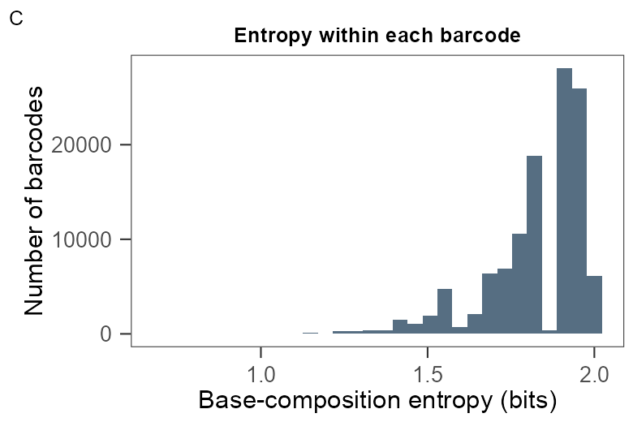

Panel C: base-composition entropy, B3_p30

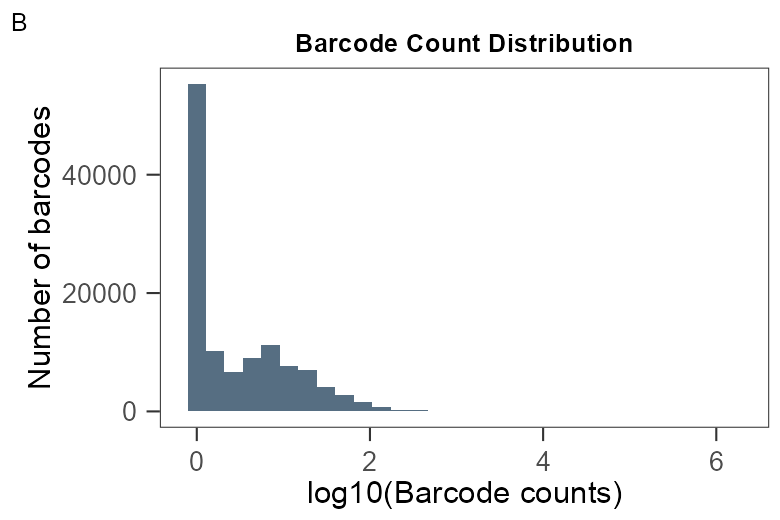

Panel B: barcode abundance, B3_p30

D · Length summary

| Length group | Sequences | Reads | Of sequences | Of reads |
| --- | --- | --- | --- | --- |
| 14 - 16 bp | 116,469 | 3,928,377 | 99.6% | 99.7% |
| < 14 bp | 434 | 11,579 | 0.4% | 0.3% |
| > 16 bp | 70 | 132 | 0.1% | 0.0% |

Sequence share = group sequences / all extracted sequences. Read share = group reads / all extracted reads. Rounded shares may not sum to exactly 100%.

**Low CMP r3 · passage 2**

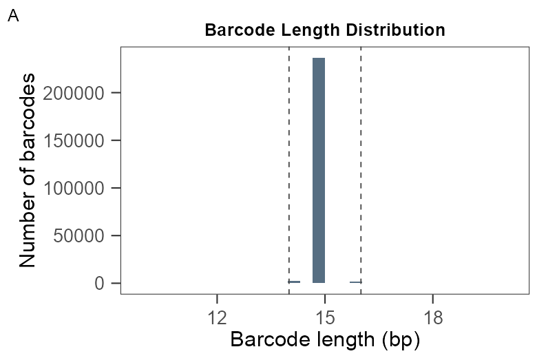

Panel A: barcode length, C3_p02

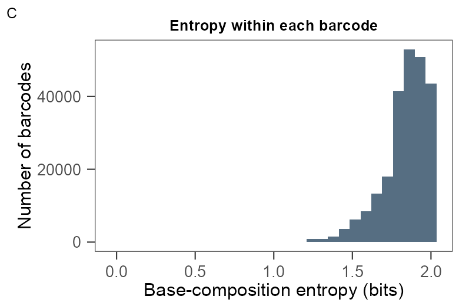

Panel C: base-composition entropy, C3_p02

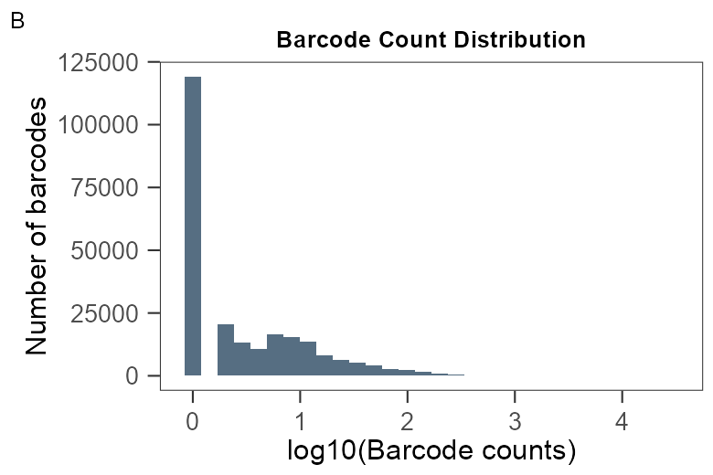

Panel B: barcode abundance, C3_p02

D · Length summary

| Length group | Sequences | Reads | Of sequences | Of reads |
| --- | --- | --- | --- | --- |
| 14 - 16 bp | 240,921 | 2,785,667 | 99.7% | 99.7% |
| < 14 bp | 714 | 7,079 | 0.3% | 0.3% |
| > 16 bp | 47 | 216 | 0.0% | 0.0% |

Sequence share = group sequences / all extracted sequences. Read share = group reads / all extracted reads. Rounded shares may not sum to exactly 100%.

**Low CMP r3 · passage 30**

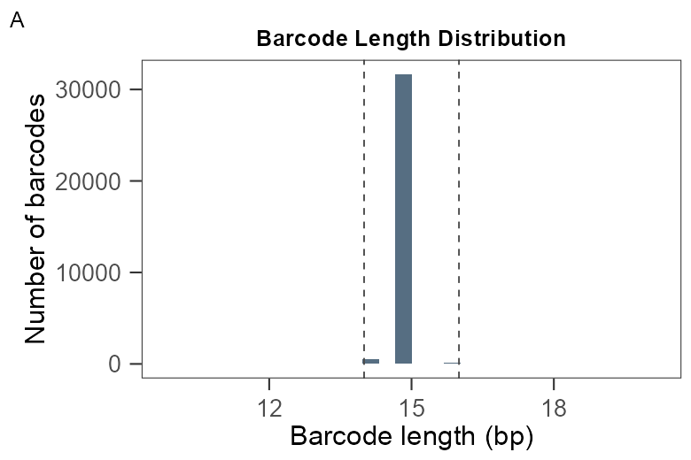

Panel A: barcode length, C3_p30

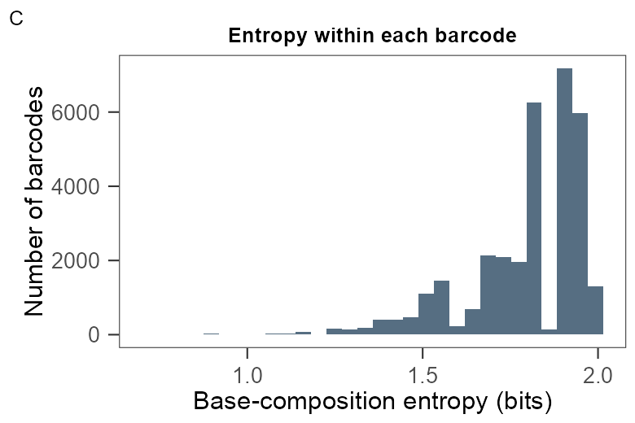

Panel C: base-composition entropy, C3_p30

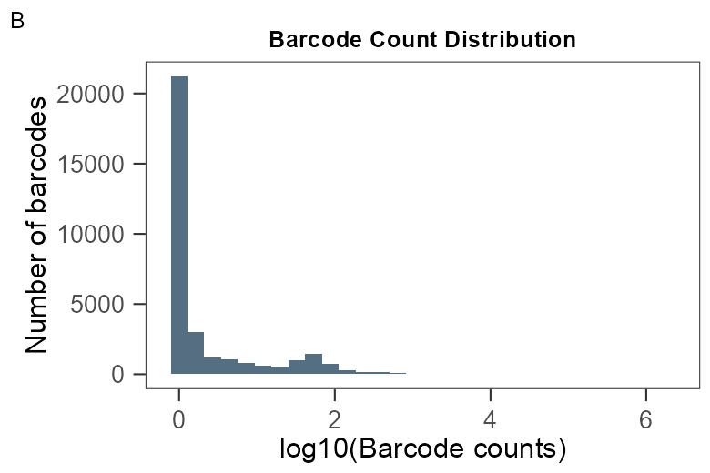

Panel B: barcode abundance, C3_p30

D · Length summary

| Length group | Sequences | Reads | Of sequences | Of reads |
| --- | --- | --- | --- | --- |
| 14 - 16 bp | 32,281 | 5,417,381 | 99.6% | 100.0% |
| < 14 bp | 116 | 771 | 0.4% | 0.0% |
| > 16 bp | 28 | 98 | 0.1% | 0.0% |

Sequence share = group sequences / all extracted sequences. Read share = group reads / all extracted reads. Rounded shares may not sum to exactly 100%.

**No drug r1 · passage 1**

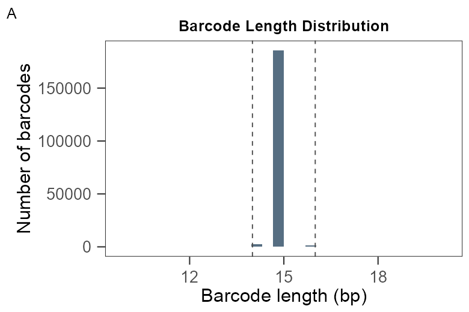

Panel A: barcode length, A1_p01

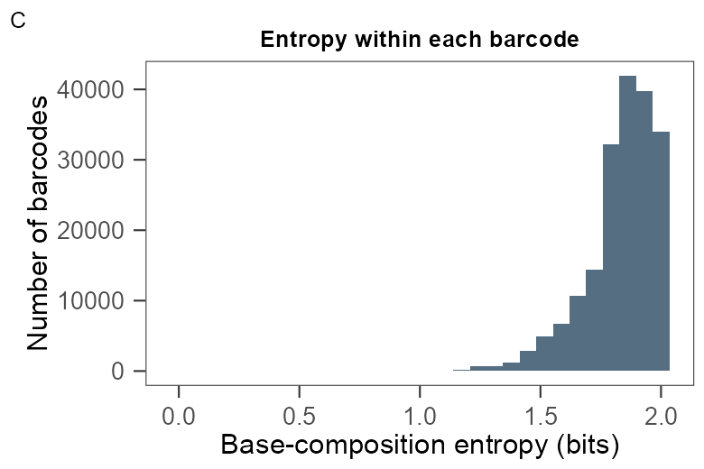

Panel C: base-composition entropy, A1_p01

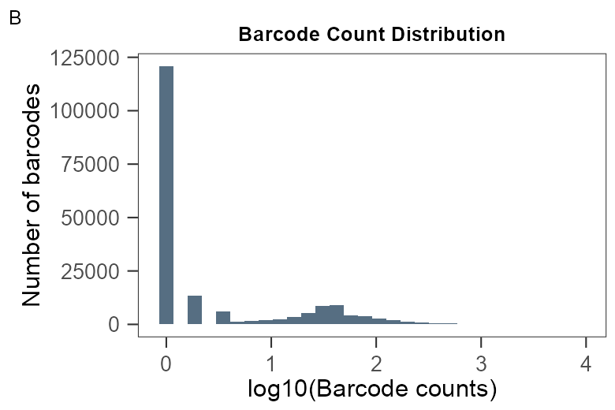

Panel B: barcode abundance, A1_p01

D · Length summary

| Length group | Sequences | Reads | Of sequences | Of reads |
| --- | --- | --- | --- | --- |
| 14 - 16 bp | 189,651 | 3,585,819 | 99.7% | 99.7% |
| < 14 bp | 571 | 9,056 | 0.3% | 0.3% |
| > 16 bp | 70 | 260 | 0.0% | 0.0% |

Sequence share = group sequences / all extracted sequences. Read share = group reads / all extracted reads. Rounded shares may not sum to exactly 100%.

**No drug r1 · passage 30**

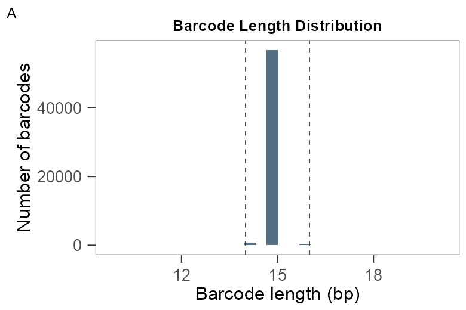

Panel A: barcode length, A1_p30

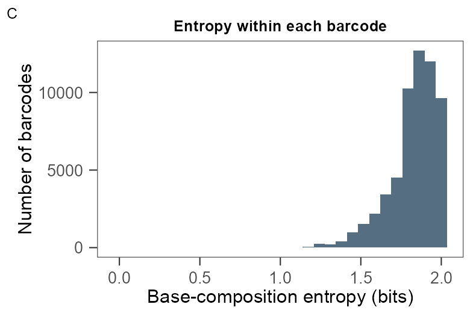

Panel C: base-composition entropy, A1_p30

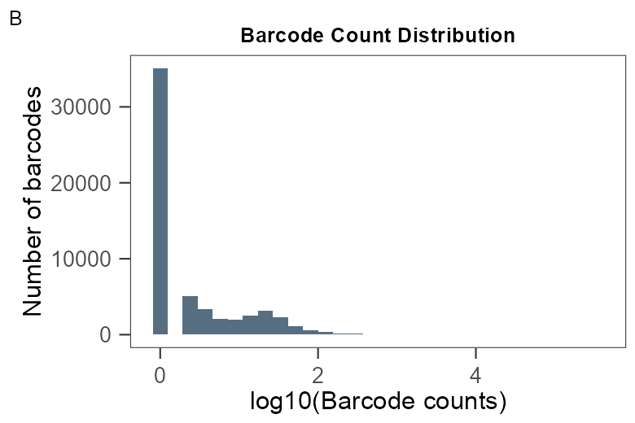

Panel B: barcode abundance, A1_p30

D · Length summary

| Length group | Sequences | Reads | Of sequences | Of reads |
| --- | --- | --- | --- | --- |
| 14 - 16 bp | 57,966 | 3,939,770 | 99.6% | 100.0% |
| < 14 bp | 196 | 1,004 | 0.3% | 0.0% |
| > 16 bp | 62 | 109 | 0.1% | 0.0% |

Sequence share = group sequences / all extracted sequences. Read share = group reads / all extracted reads. Rounded shares may not sum to exactly 100%.

**No drug r2 · passage 1**

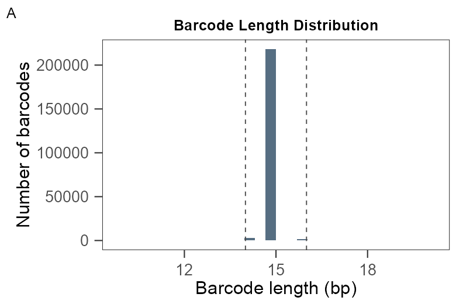

Panel A: barcode length, B1_p01

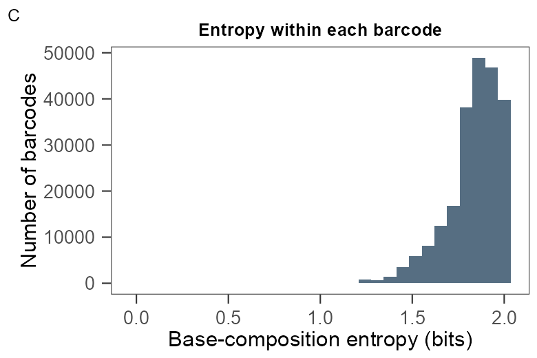

Panel C: base-composition entropy, B1_p01

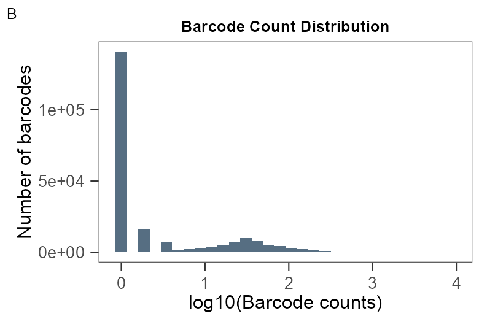

Panel B: barcode abundance, B1_p01

D · Length summary

| Length group | Sequences | Reads | Of sequences | Of reads |
| --- | --- | --- | --- | --- |
| 14 - 16 bp | 222,818 | 4,348,012 | 99.7% | 99.8% |
| < 14 bp | 657 | 9,838 | 0.3% | 0.2% |
| > 16 bp | 68 | 258 | 0.0% | 0.0% |

Sequence share = group sequences / all extracted sequences. Read share = group reads / all extracted reads. Rounded shares may not sum to exactly 100%.

**No drug r2 · passage 30**

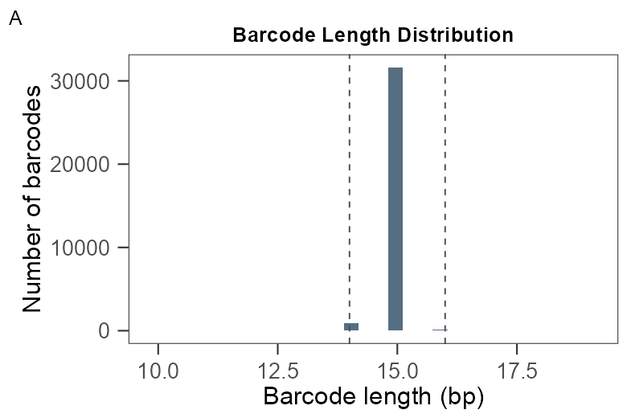

Panel A: barcode length, B1_p30

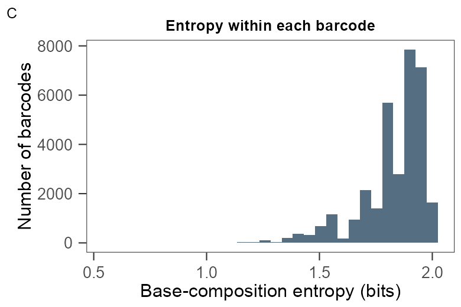

Panel C: base-composition entropy, B1_p30